# Análise exploratório dataset **dados_execicios.csv**

Rafael De Pauli Baptista

25/05/2024

# Descrição do dataset

## Visualização

| Gender | Age | Occupation | Sleep.Duration | Quality.of.Sleep | Physical.Activity.Level | Stress.Level | BMI.Category | Heart.Rate | Daily.Steps | Sleep.Disorder |
| --- | --- | --- | --- | --- | --- | --- | --- | --- | --- | --- |
| Male | 27 | Software Engineer | 6.1 | 6 | 42 | 6 | Overweight | 77 | 4200 | None |
| Male | 28 | Doctor | 6.2 | 6 | 60 | 8 | Normal | 75 | 10000 | None |
| Male | 28 | Doctor | 6.2 | 6 | 60 | 8 | Normal | 75 | 10000 | None |
| Male | 28 | Sales Representative | 5.9 | 4 | 30 | 8 | Obese | 85 | 3000 | Sleep Apnea |
| Male | 28 | Sales Representative | 5.9 | 4 | 30 | 8 | Obese | 85 | 3000 | Sleep Apnea |
| Male | 28 | Software Engineer | 5.9 | 4 | 30 | 8 | Obese | 85 | 3000 | Insomnia |

**Análise parcial**: Podemos verificar que o dataset traz informações sobre pessoas, suas profissões, nível de estresse e alguns indicadores de qualidade de vida.

## Sumário

|  | Gender | Age | Occupation | Sleep.Duration | Quality.of.Sleep | Physical.Activity.Level | Stress.Level | BMI.Category | Heart.Rate | Daily.Steps | Sleep.Disorder |
| --- | --- | --- | --- | --- | --- | --- | --- | --- | --- | --- | --- |
|  | Female:185 | Min. :27.00 | Nurse :73 | Min. :5.800 | Min. :4.000 | Min. :30.00 | Min. :3.000 | Normal :216 | Min. :65.00 | Min. : 3000 | Insomnia : 77 |
|  | Male :189 | 1st Qu.:35.25 | Doctor :71 | 1st Qu.:6.400 | 1st Qu.:6.000 | 1st Qu.:45.00 | 1st Qu.:4.000 | Overweight:148 | 1st Qu.:68.00 | 1st Qu.: 5600 | None :219 |
|  | NA | Median :43.00 | Engineer :63 | Median :7.200 | Median :7.000 | Median :60.00 | Median :5.000 | Obese : 10 | Median :70.00 | Median : 7000 | Sleep Apnea: 78 |
|  | NA | Mean :42.18 | Lawyer :47 | Mean :7.132 | Mean :7.313 | Mean :59.17 | Mean :5.385 | NA | Mean :70.17 | Mean : 6817 | NA |
|  | NA | 3rd Qu.:50.00 | Teacher :40 | 3rd Qu.:7.800 | 3rd Qu.:8.000 | 3rd Qu.:75.00 | 3rd Qu.:7.000 | NA | 3rd Qu.:72.00 | 3rd Qu.: 8000 | NA |
|  | NA | Max. :59.00 | Accountant:37 | Max. :8.500 | Max. :9.000 | Max. :90.00 | Max. :8.000 | NA | Max. :86.00 | Max. :10000 | NA |
|  | NA | NA | (Other) :43 | NA | NA | NA | NA | NA | NA | NA | NA |

**Análise parcial**:

- Quantidade de homens e mullheres muito próximos;
- A dispersão da idades das pessoas não é muito grande (entre 27 à 59 anos);
- Média de tempo de sono é compatível com a média mundial;
- A maioria das pessoas não tem disordem do sono.

# Análise variáveis qualitativas

## Gênero

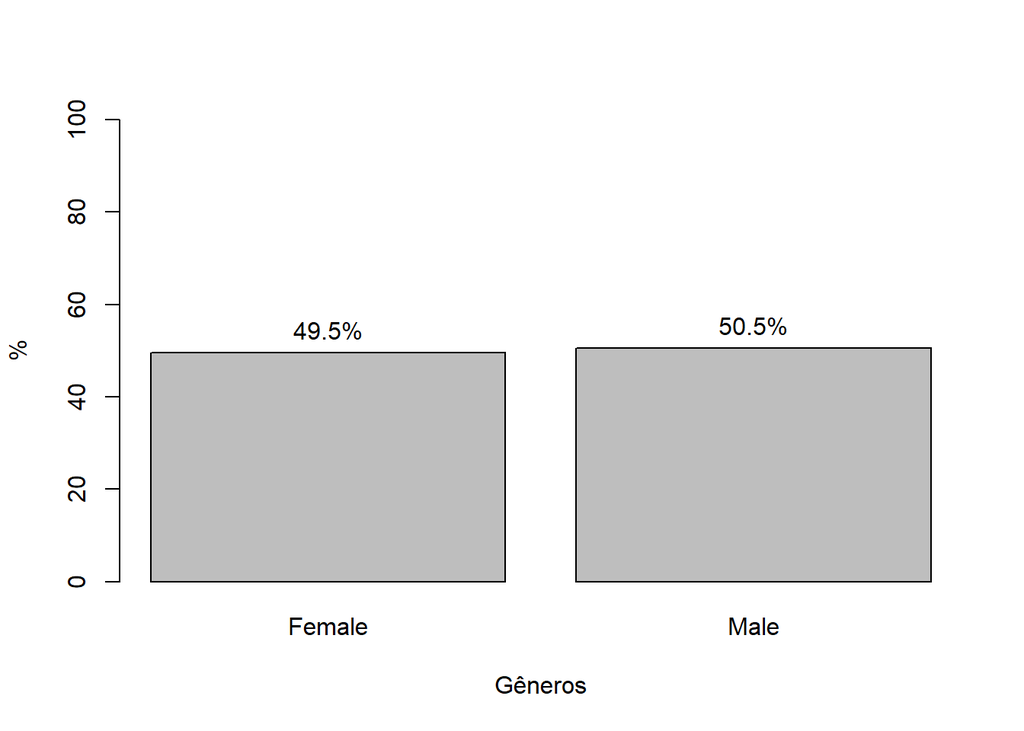

**Análise parcial**: Confirmação que o número de homens e mulheres são muito próximos

## Ocupação

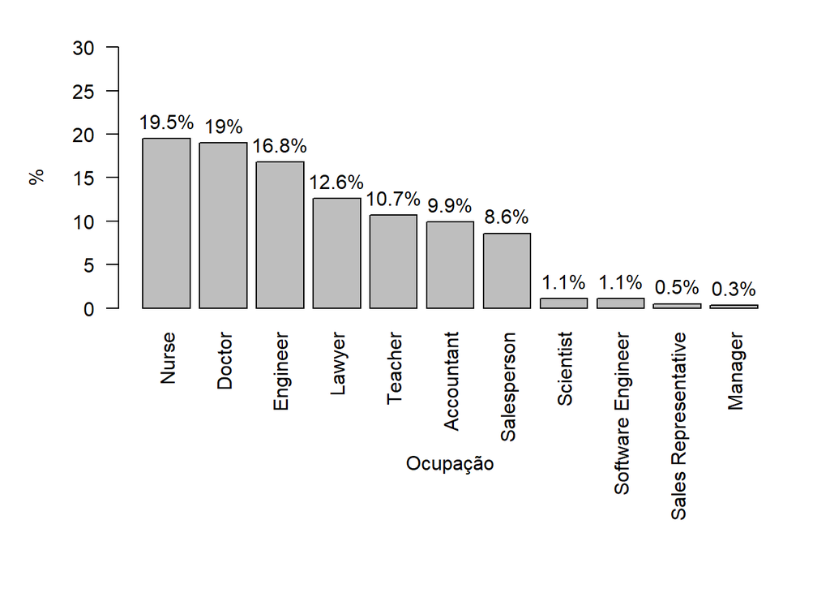

**Análise parcial**: A maioria das pessoas são enfermeiros(as), médicos(as) ou engenheiros(as)

# Análise variáveis quantitativas

## Idade

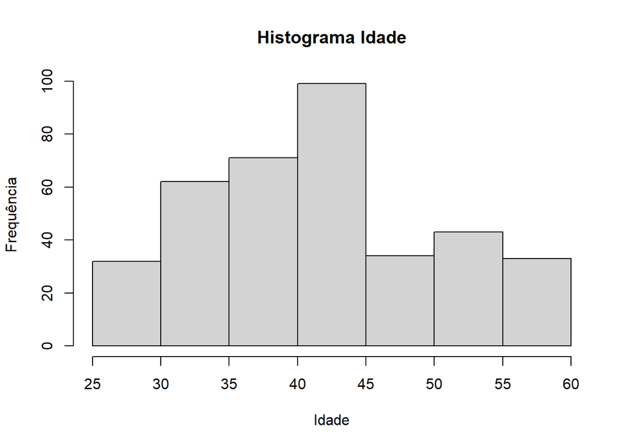

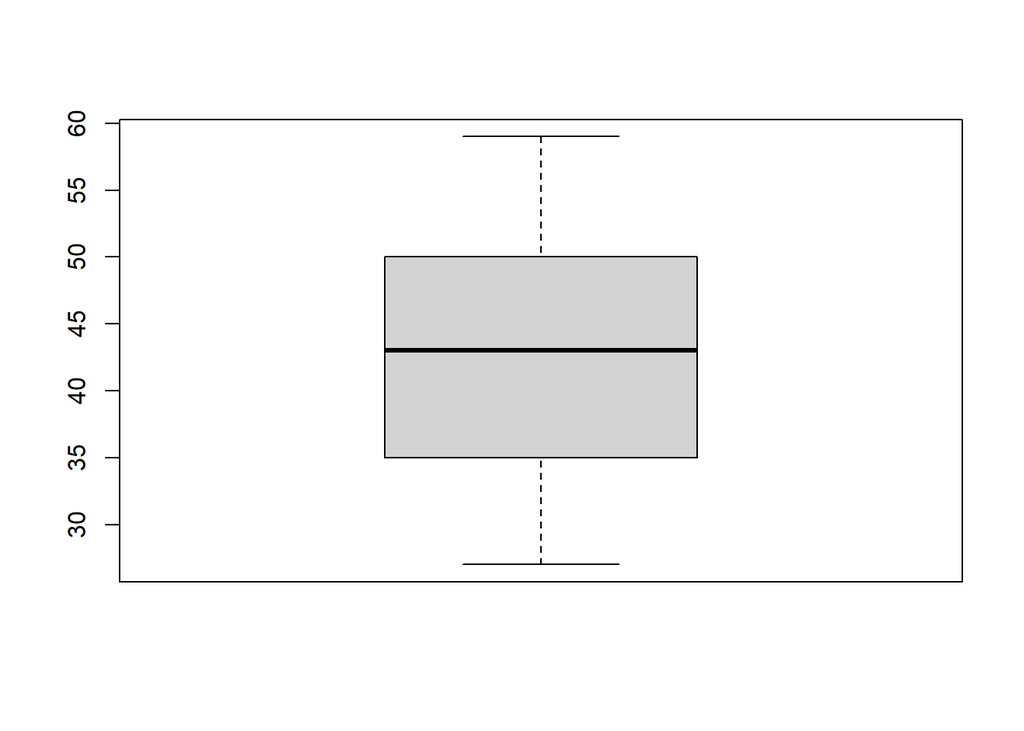

# Análise exploratória de duas variáveis

## Relação entre variável qualitativa e variável quantitativa

| Gênero | Qualidade do Sono 4 | Qualidade do Sono 5 | Qualidade do Sono 6 | Qualidade do Sono 7 | Qualidade do Sono 8 | Qualidade do Sono 9 | Qualidade do Sono Sum |
| --- | --- | --- | --- | --- | --- | --- | --- |
| Female | 0,53% | 1,07% | 9,89% | 9,89% | 9,63% | 18,45% | 49,46% |
| Male | 0,8% | 0,8% | 18,18% | 10,7% | 19,52% | 0,53% | 50,53% |
| Sum | 1,33% | 1,87% | 28,07% | 20,59% | 29,15% | 18,98% | 99,99% |

| Gênero | Qualidade do Sono 4 | Qualidade do Sono 5 | Qualidade do Sono 6 | Qualidade do Sono 7 | Qualidade do Sono 8 | Qualidade do Sono 9 |
| --- | --- | --- | --- | --- | --- | --- |
| Female | 40% | 57,14% | 35,24% | 48,05% | 33,03% | 97,18% |
| Male | 60% | 42,86% | 64,76% | 51,95% | 66,97% | 2,82% |
| Sum | 100% | 100% | 100% | 100% | 100% | 100% |

**Análise parcial**: Das pessoas qe possuem uma qualidade de sono ótima, 97,18% são mulheres.

## Relação entre duas variáveis quantitativas

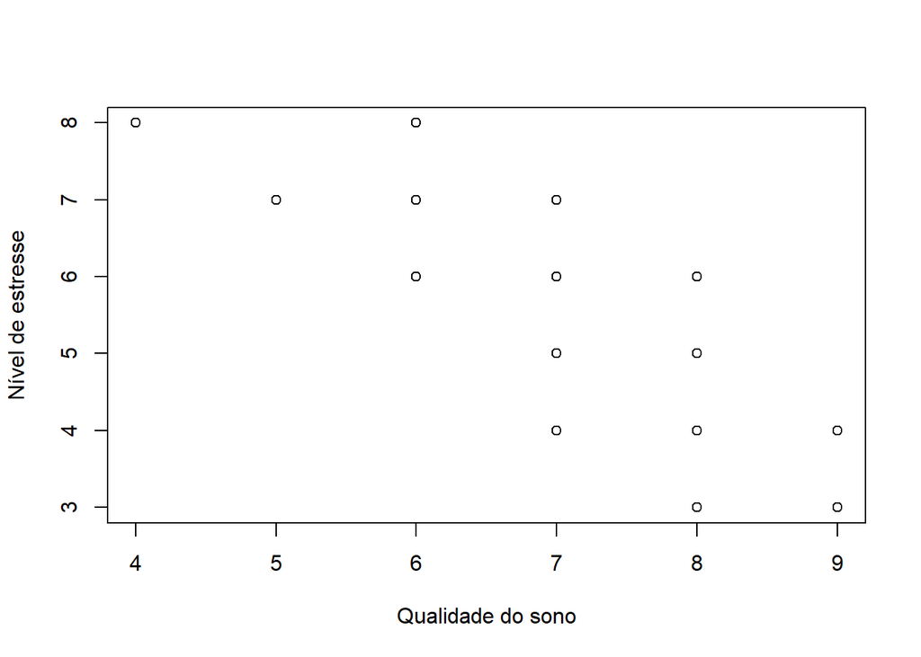

| Correlação entre qualidade de sono e nível de estresse |
| --- |
| -0.898752 |

**Análise parcial**: Conseguimos perceber que a qualidade do sono e o nível de estresse possuem uma relação forte.

## Relação entre uma variável qualitativa e quantitativa

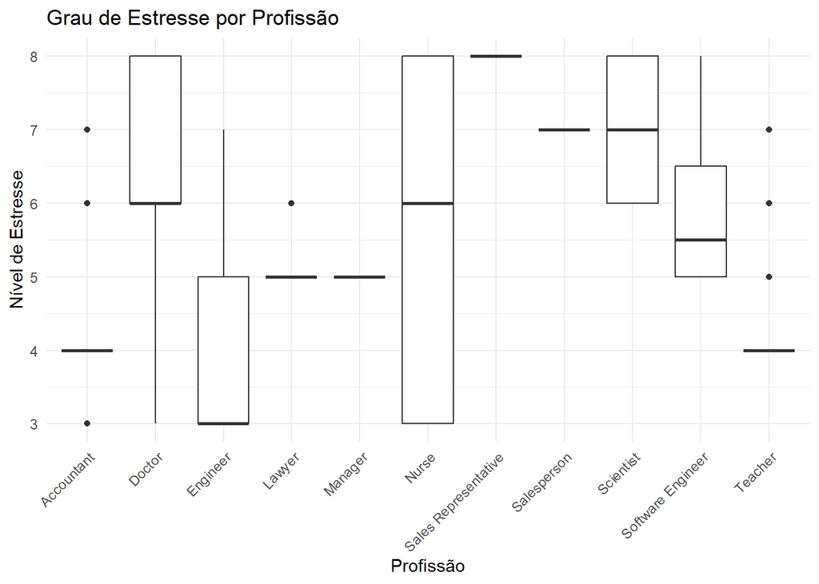

| Relação entre Ocupação e Nível de Estresse por profissão | Relação entre Ocupação e Nível de Estresse por profissão 3 | Relação entre Ocupação e Nível de Estresse por profissão 4 | Relação entre Ocupação e Nível de Estresse por profissão 5 | Relação entre Ocupação e Nível de Estresse por profissão 6 | Relação entre Ocupação e Nível de Estresse por profissão 7 | Relação entre Ocupação e Nível de Estresse por profissão 8 |
| --- | --- | --- | --- | --- | --- | --- |
| Accountant | 5,4% | 70,3% | 0% | 8,1% | 16,2% | 0% |
| Doctor | 5,6% | 0% | 2,8% | 45,1% | 0% | 46,5% |
| Engineer | 54% | 14,3% | 25,4% | 1,6% | 4,8% | 0% |
| Lawyer | 0% | 0% | 93,6% | 6,4% | 0% | 0% |
| Manager | 0% | 0% | 100% | 0% | 0% | 0% |
| Nurse | 42,5% | 5,5% | 0% | 2,7% | 5,5% | 43,8% |
| Sales Representative | 0% | 0% | 0% | 0% | 0% | 100% |
| Salesperson | 0% | 0% | 0% | 0% | 100% | 0% |
| Scientist | 0% | 0% | 0% | 50% | 0% | 50% |
| Software Engineer | 0% | 0% | 50% | 25% | 0% | 25% |
| Teacher | 0% | 77,5% | 5% | 5% | 12,5% | 0% |

| Relação entre Ocupação e Nível de Estresse comparado por profissão | Relação entre Ocupação e Nível de Estresse comparado por profissão 3 | Relação entre Ocupação e Nível de Estresse comparado por profissão 4 | Relação entre Ocupação e Nível de Estresse comparado por profissão 5 | Relação entre Ocupação e Nível de Estresse comparado por profissão 6 | Relação entre Ocupação e Nível de Estresse comparado por profissão 7 | Relação entre Ocupação e Nível de Estresse comparado por profissão 8 |
| --- | --- | --- | --- | --- | --- | --- |
| Accountant | 2,8% | 37,1% | 0% | 6,5% | 12% | 0% |
| Doctor | 5,6% | 0% | 3% | 69,6% | 0% | 47,1% |
| Engineer | 47,9% | 12,9% | 23,9% | 2,2% | 6% | 0% |
| Lawyer | 0% | 0% | 65,7% | 6,5% | 0% | 0% |
| Manager | 0% | 0% | 1,5% | 0% | 0% | 0% |
| Nurse | 43,7% | 5,7% | 0% | 4,3% | 8% | 45,7% |
| Sales Representative | 0% | 0% | 0% | 0% | 0% | 2,9% |
| Salesperson | 0% | 0% | 0% | 0% | 64% | 0% |
| Scientist | 0% | 0% | 0% | 4,3% | 0% | 2,9% |
| Software Engineer | 0% | 0% | 3% | 2,2% | 0% | 1,4% |
| Teacher | 0% | 44,3% | 3% | 4,3% | 10% | 0% |

| Relação entre Idade e Nível de Estresse comparado por idade | Relação entre Idade e Nível de Estresse comparado por idade 3 | Relação entre Idade e Nível de Estresse comparado por idade 4 | Relação entre Idade e Nível de Estresse comparado por idade 5 | Relação entre Idade e Nível de Estresse comparado por idade 6 | Relação entre Idade e Nível de Estresse comparado por idade 7 | Relação entre Idade e Nível de Estresse comparado por idade 8 |
| --- | --- | --- | --- | --- | --- | --- |
| 27 | 0% | 0% | 0% | 2,2% | 0% | 0% |
| 28 | 0% | 0% | 0% | 0% | 0% | 7,1% |
| 29 | 0% | 0% | 0% | 8,7% | 6% | 8,6% |
| 30 | 0% | 0% | 0% | 23,9% | 4% | 0% |
| 31 | 0% | 1,4% | 0% | 30,4% | 0% | 4,3% |
| 32 | 2,8% | 0% | 0% | 8,7% | 0% | 15,7% |
| 33 | 0% | 0% | 0% | 4,3% | 0% | 15,7% |
| 34 | 0% | 0% | 0% | 0% | 0% | 2,9% |
| 35 | 0% | 10% | 7,5% | 0% | 0% | 0% |
| 36 | 0% | 14,3% | 0% | 0% | 4% | 0% |
| 37 | 0% | 22,9% | 4,5% | 2,2% | 0% | 0% |
| 38 | 0% | 11,4% | 17,9% | 0% | 0% | 0% |
| 39 | 2,8% | 0% | 16,4% | 2,2% | 2% | 0% |
| 40 | 0% | 0% | 3% | 4,3% | 0% | 0% |
| 41 | 0% | 0% | 13,4% | 6,5% | 0% | 0% |
| 42 | 0% | 0% | 9% | 0% | 6% | 0% |
| 43 | 0% | 5,7% | 23,9% | 0% | 28% | 0% |
| 44 | 0% | 15,7% | 0% | 0% | 38% | 0% |
| 45 | 0% | 15,7% | 1,5% | 4,3% | 0% | 0% |
| 48 | 0% | 0% | 3% | 0% | 0% | 1,4% |
| 49 | 2,8% | 0% | 0% | 0% | 0% | 12,9% |
| 50 | 1,4% | 0% | 0% | 0% | 0% | 27,1% |
| 51 | 5,6% | 0% | 0% | 2,2% | 0% | 4,3% |
| 52 | 4,2% | 0% | 0% | 0% | 12% | 0% |
| 53 | 23,9% | 0% | 0% | 0% | 0% | 0% |
| 54 | 9,9% | 0% | 0% | 0% | 0% | 0% |
| 55 | 0% | 2,9% | 0% | 0% | 0% | 0% |
| 56 | 2,8% | 0% | 0% | 0% | 0% | 0% |
| 57 | 12,7% | 0% | 0% | 0% | 0% | 0% |
| 58 | 8,5% | 0% | 0% | 0% | 0% | 0% |
| 59 | 22,5% | 0% | 0% | 0% | 0% | 0% |

**Análise parcial**:

- Percebemos que o nível de estresse da profissão enfermeiro(a) possuem um variabilidade bem grande;
  - Existe extremos nessa profissão: ou a pessoa possui um nível de estresse bem baixo ou bem alto.
- Considerando a quantidade de cientistas, podemos perceber que essa profissão possui um nível de estresse elevado;
- Engenheiros possuem um nível de estresse baixo;
- As idades mais estressantes são de 32, 33, 49 e 50 anos.

### Análise exploratória de várias variáveis

## Partição e janelamento

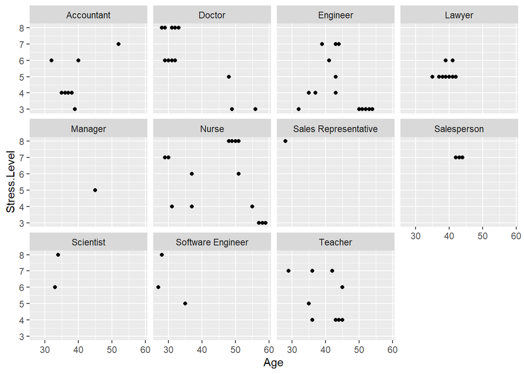

| Tabela de correlação | Tabela de correlação Age | Tabela de correlação Sleep.Duration | Tabela de correlação Quality.of.Sleep | Tabela de correlação Physical.Activity.Level | Tabela de correlação Stress.Level | Tabela de correlação Heart.Rate | Tabela de correlação Daily.Steps |
| --- | --- | --- | --- | --- | --- | --- | --- |
| Age | 1.0000000 | 0.3447094 | 0.4737339 | 0.1789927 | -0.4223445 | -0.2256062 | 0.0579734 |
| Sleep.Duration | 0.3447094 | 1.0000000 | 0.8832130 | 0.2123603 | -0.8110230 | -0.5164549 | -0.0395325 |
| Quality.of.Sleep | 0.4737339 | 0.8832130 | 1.0000000 | 0.1928965 | -0.8987520 | -0.6598647 | 0.0167914 |
| Physical.Activity.Level | 0.1789927 | 0.2123603 | 0.1928965 | 1.0000000 | -0.0341345 | 0.1369710 | 0.7727231 |
| Stress.Level | -0.4223445 | -0.8110230 | -0.8987520 | -0.0341345 | 1.0000000 | 0.6700265 | 0.1868290 |
| Heart.Rate | -0.2256062 | -0.5164549 | -0.6598647 | 0.1369710 | 0.6700265 | 1.0000000 | -0.0303086 |
| Daily.Steps | 0.0579734 | -0.0395325 | 0.0167914 | 0.7727231 | 0.1868290 | -0.0303086 | 1.0000000 |

**Análise parcial**:

- Qualidade e Duração do Sono têm uma correlação positiva forte entre si, indicando que mais horas de sono estão associadas a uma melhor qualidade do sono.
- Nível de Estresse tem correlações negativas fortes com qualidade e duração do sono, indicando que mais estresse está associado a pior qualidade e menor duração do sono.
- Frequência Cardíaca está moderadamente correlacionada com nível de estresse e qualidade do sono, sugerindo que maior estresse e pior qualidade do sono estão associados a uma maior frequência cardíaca.
- Nível de Atividade Física e Passos Diários têm uma correlação positiva moderada, indicando que mais atividade física está associada a mais passos diários.

# Conclusão da Análise Exploratória

Após realizar uma análise exploratória dos dados disponíveis, podemos destacar os seguintes pontos principais:

1. Qualidade do Sono e Nível de Estresse

Observamos uma forte correlação negativa entre a qualidade do sono e o nível de estresse. Isso indica que indivíduos com uma melhor qualidade de sono tendem a ter níveis de estresse mais baixos. Essa relação é fundamental para entender a importância do sono na regulação do estresse.

3. Distribuição de Dados

5. Recomendações para Intervenções

Com base nos dados analisados, recomenda-se focar em intervenções que melhorem a qualidade e a duração do sono dos indivíduos, especialmente aqueles em profissões de alta demanda, para reduzir o estresse e melhorar o bem-estar geral.

Em resumo, a análise exploratória destaca a importância da qualidade e quantidade de sono na gestão do estresse e identifica profissões que podem se beneficiar de intervenções específicas para melhorar a saúde mental e física dos trabalhadores.